# Demonstrating Regressors Using Boston Housing Dataset

### By Ciaran Lowell

[figure not shown]

This project showcases multiple different regression methods and compares the accuracy of those methods. Note that these regressors will be using arbitrarily chosen hyperparameters and have not necessarily been tuned for best possible performance.

I had planned to show model residuals using the Yellowbrick library, but it did not cooperate well with some of the Regressor libraries, so I instead used a simple pyplot function that I coded.

### Methods Compared

1. Linear Regression
2. Neural Network
3. [XGBoost](https://xgboost.readthedocs.io/en/latest/tutorials/model.html)
4. Support Vector Regression
5. Kernel Weighted Local Regression
   - Gaussian Kernel
   - Aitchison Aitken Kernel

### Data

This project used the [Boston Housing Dataset](https://www.cs.toronto.edu/~delve/data/boston/bostonDetail.html). Specifically, I used the "Median Number of Rooms" variable to predict the house price. The observations correspond to the "Median Number of Rooms" and "Median House Price" within neighborhoods of Boston.

The dataset is small and represents only 506 observations. The small size of the dataset resulted in overfitting issues with some of the models. In the future, KFold Cross-Validation would likely need to be used to reduce overfitting problems.

The dataset appears to have been "censored" at $50,000, with an unusual number of datapoints recording that exact price.

```python
from google.colab import drive
drive.mount('/content/drive')
```

```python
cd /content/drive/MyDrive/Colab Notebooks/VasiliuLectures
```

```
/content/drive/MyDrive/Colab Notebooks/VasiliuLectures
```

```python
#! pip install --upgrade Cython
#! pip install --upgrade git+https://github.com/statsmodels/statsmodels
import statsmodels.api as sm
```

```python
import pandas as pd
import numpy as np
import matplotlib.pyplot as plt
import keras
from keras.models import Sequential
from keras.layers import Dense
from keras.layers import Dropout
from sklearn.metrics import r2_score
from keras.optimizers import Adam
from keras.callbacks import EarlyStopping
from matplotlib import rc
import sklearn.metrics as skm
from sklearn.base import BaseEstimator, RegressorMixin
```

```python
def graphResiduals(modelName, X_test_input, y_test_input, y_pred_input):
  y_hat = abs(y_pred_input - y_test_input)
  plt.scatter(X_test_input,y_hat, color  = 'red')
  plt.title('%s Error Residuals' % (modelName))
  plt.xlabel("Median Number of Rooms")
  plt.ylabel("Residual Error (in Thousands of Dollars)")
  plt.show()
```

```python
def graphResults(modelName, X_input, y_input,  X_test_input, y_pred_input):
  plt.scatter(X_input, y_input)
  plt.plot(X_test_input, y_pred_input, color='red', label = modelName)
  plt.title('%s- # of Rooms vs. Price' % (modelName))
  plt.xlabel("Median Number of Rooms")
  plt.ylabel("House Price (units = $1000)")
  plt.legend()
  plt.show()
```

```python
def printMetrics(modelName, y_test_input, y_pred_input):
  print("*%s* Metrics: " % (modelName))
  print("Mean absolute error = $", round(skm.mean_absolute_error(y_test_input, y_pred_input)*1000, 2))
  print("Mean squared error = $", round(skm.mean_squared_error(y_test_input, y_pred_input)*1000, 2))
  print("Median absolute error = $", round(skm.median_absolute_error(y_test_input, y_pred_input)*1000, 2))
  print("R2 score =", round(skm.r2_score(y_test_input, y_pred_input), 2))
```

```python
bostonHousing = pd.read_csv('boston_housing_data.csv')
```

```python
bostonHousing
```

|  | town | tract | longitude | latitude | crime | residential | industrial | river | nox | rooms | older | distance | highway | tax | ptratio | lstat | cmedv |
| --- | --- | --- | --- | --- | --- | --- | --- | --- | --- | --- | --- | --- | --- | --- | --- | --- | --- |
| 0 | Nahant | 2011 | -70.955002 | 42.255001 | 0.00632 | 18.0 | 2.31 | no | 0.538 | 6.575 | 65.199997 | 4.0900 | 1 | 296 | 15.300000 | 4.98 | 24.000000 |
| 1 | Swampscott | 2021 | -70.949997 | 42.287498 | 0.02731 | 0.0 | 7.07 | no | 0.469 | 6.421 | 78.900002 | 4.9671 | 2 | 242 | 17.799999 | 9.14 | 21.600000 |
| 2 | Swampscott | 2022 | -70.935997 | 42.283001 | 0.02729 | 0.0 | 7.07 | no | 0.469 | 7.185 | 61.099998 | 4.9671 | 2 | 242 | 17.799999 | 4.03 | 34.700001 |
| 3 | Marblehead | 2031 | -70.928001 | 42.292999 | 0.03237 | 0.0 | 2.18 | no | 0.458 | 6.998 | 45.799999 | 6.0622 | 3 | 222 | 18.700001 | 2.94 | 33.400002 |
| 4 | Marblehead | 2032 | -70.921997 | 42.298000 | 0.06905 | 0.0 | 2.18 | no | 0.458 | 7.147 | 54.200001 | 6.0622 | 3 | 222 | 18.700001 | 5.33 | 36.200001 |
| ... | ... | ... | ... | ... | ... | ... | ... | ... | ... | ... | ... | ... | ... | ... | ... | ... | ... |
| 501 | Winthrop | 1801 | -70.986000 | 42.231201 | 0.06263 | 0.0 | 11.93 | no | 0.573 | 6.593 | 69.099998 | 2.4786 | 1 | 273 | 21.000000 | 9.67 | 22.400000 |
| 502 | Winthrop | 1802 | -70.990997 | 42.227501 | 0.04527 | 0.0 | 11.93 | no | 0.573 | 6.120 | 76.699997 | 2.2875 | 1 | 273 | 21.000000 | 9.08 | 20.600000 |
| 503 | Winthrop | 1803 | -70.994797 | 42.226002 | 0.06076 | 0.0 | 11.93 | no | 0.573 | 6.976 | 91.000000 | 2.1675 | 1 | 273 | 21.000000 | 5.64 | 23.900000 |
| 504 | Winthrop | 1804 | -70.987503 | 42.223999 | 0.10959 | 0.0 | 11.93 | no | 0.573 | 6.794 | 89.300003 | 2.3889 | 1 | 273 | 21.000000 | 6.48 | 22.000000 |
| 505 | Winthrop | 1805 | -70.982498 | 42.221001 | 0.04741 | 0.0 | 11.93 | no | 0.573 | 6.030 | 80.800003 | 2.5050 | 1 | 273 | 21.000000 | 7.88 | 19.000000 |

506 rows × 17 columns

```python
X = bostonHousing['rooms'].values.reshape(-1,1)
y = bostonHousing['cmedv'].values.reshape(-1,1)
dat = np.concatenate([X,y.reshape(-1,1)], axis=1)
```

```python
from sklearn.model_selection import train_test_split as tts
X_train, X_test, y_train, y_test = tts(X, y, test_size = 0.20, random_state = 2001)
```

```python
dat_train = np.concatenate([X_train,y_train.reshape(-1,1)], axis=1)
dat_train = dat_train[np.argsort(dat_train[:, 0])]
```

```python
dat_test = np.concatenate([X_test,y_test.reshape(-1,1)], axis=1)
dat_test = dat_test[np.argsort(dat_test[:, 0])]
```

```python
X_test_reshape = dat_test[:,0].reshape((dat_test[:,0].shape[0]), 1)
y_test_reshape = dat_test[:,1].reshape((dat_test[:,0].shape[0]), 1)
```

## Linear Regression

A simple linear regression is fit to the data using SKLearn's Linear Regression package. The regressor is not fit to intercept the origin.

The linear regressor's residual plot somewhat fits the normal distribution, but shows greater errors past 7 rooms.

```python
from sklearn.linear_model import LinearRegression
linear_regressor = LinearRegression()
linear = linear_regressor.fit(X_train, y_train)
y_pred_lr = linear.predict(dat_test[:,0].reshape((dat_test[:,0].shape[0]), 1))
```

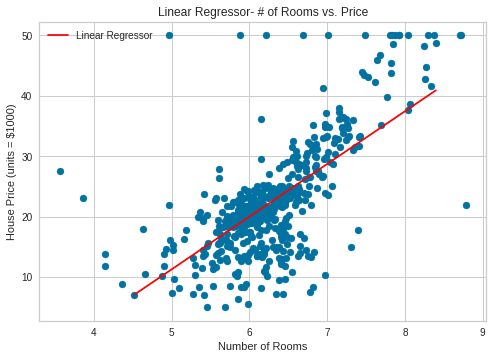

```python
graphResults('Linear Regressor', X, y, X_test_reshape, y_pred_lr)
```

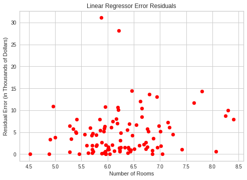

```python
y_pred = linear.predict(y_test)
graphResiduals('Linear Regressor',X_test_reshape, y_test_reshape, y_pred_lr)
```

## XGBoost

XGBoost stands for "Extreme Gradient Boosting." The model creates a forest of decision trees.

XGBoost is an extremely powerful algorithm that utilizes boosted decision trees to quickly make predictions. Unfortunately, it also is prone to overfitting. The XGBoost model created by the Test dataset seems to be overfit. I adjusted the input parameters and reduced some of the overfitting, but the model still appears overfit on the data.

The residual plot follows a normal distribution.

```python
import xgboost as xgb
xg_regressor = xgb.XGBRegressor(objective = "reg:squarederror", n_estimators = 100, reg_lambda = 10, alpha = 50, gamma = 100, max_depth = 3, strict_shape = True)
xg_regressor.fit(X_train, y_train)
y_pred_xgb = xg_regressor.predict(X_test_reshape).reshape(X_test_reshape.shape[0], 1)
```

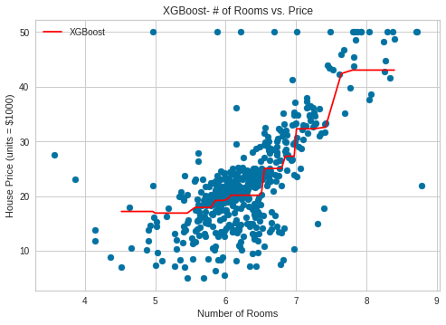

```python
graphResults("XGBoost", X, y, X_test_reshape, y_pred_xgb)
```

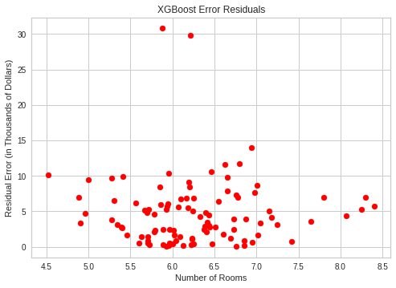

```python
graphResiduals("XGBoost", X_test_reshape, y_test_reshape, y_pred_xgb)
```

## Support Vector Regression

Support Vector Regression uses Support Vector Machines to find optimal hyperplanes for variable prediction. This model has been fit using the default hyperparameters from the SKlearn Support Vector Regression toolkit.

The graph shows SVR developing a sigmoid-esque shape for predicting this data. The residuals appear to be homoscedastic and follow a normal distribution.

```python
from sklearn.svm import SVR
SupportVR = SVR()
SupportVR.fit(X_train,y_train)
y_pred_SVR = SupportVR.predict(X_test_reshape).reshape(X_test_reshape.shape[0], 1)
```

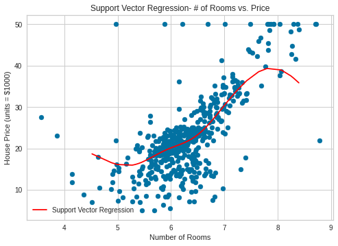

```python
graphResults("Support Vector Regression", X, y, X_test_reshape, y_pred_SVR)
```

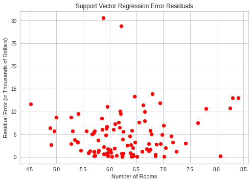

```python
graphResiduals("Support Vector Regression", X_test_reshape, y_test_reshape, y_pred_SVR)
```

## Neural Net

This Neural Net is a simple 5-layer model that uses Dense layers with a relu activation function. The net has been optimized to reduce Mean Squared Error using the Adam optimizer, and has an Early Stopping parameter to prevent overfitting and excessive runtime.

The Neural Net's line of best fit takes the form of 3 different piecewise linear functions.

The Residuals appear homoscedastic.

```python
model = Sequential()
model.add(Dense(128, activation="relu", input_dim=1))
model.add(Dense(64, activation = "relu"))
model.add(Dense(32, activation="relu"))
model.add(Dense(8, activation="relu"))
model.add(Dense(1, activation="linear"))

model.compile(loss='mean_squared_error', optimizer=Adam(lr=1e-3, decay=1e-3 / 200))

es = EarlyStopping(monitor='val_loss', mode='min', verbose=1, patience=1000)

history = model.fit(X_train, y_train, validation_split=0.3, epochs=1000, batch_size=100, verbose=0, callbacks=[es])
```

```python
# Calculate predictions
y_pred_nn = model.predict(X_test_reshape)
```

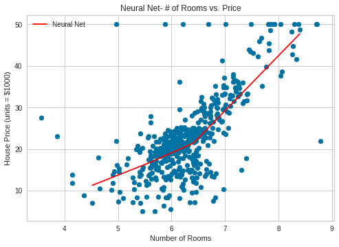

```python
graphResults("Neural Net", X, y, X_test_reshape, y_pred_nn)
```

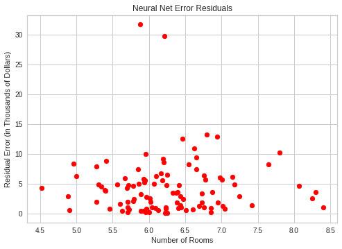

```python
graphResiduals("Neural Net", X_test_reshape, y_test_reshape, y_pred_nn)
```

## Weighted Kernel Regressions

The StatsModels Kernel Regression package provides the ability to implment Weighted Kernel Regressions while specifying the type of kernel to use.

Illustrated below are usages of the Gaussian kernel and the Aitchison Aitken Kernel.

### Gaussian Kernel

The line of fit for this model looks similar to the Support Vector line. The residuals are homoscedastic and normally distributed.

```python
from statsmodels.nonparametric.kernel_regression import KernelReg

model_KernRegGauss = KernelReg(endog=y_train,exog=X_train,var_type='c', ckertype='gaussian')
```

```python
yhat_smG, y_stdG = model_KernRegGauss.fit(X_test_reshape)
```

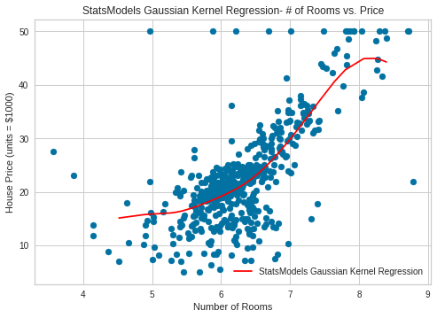

```python
graphResults("StatsModels Gaussian Kernel Regression", X, y, X_test_reshape, yhat_smG)
```

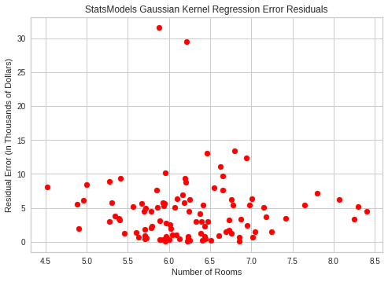

```python
yhat_smG = yhat_smG.reshape((dat_test[:,0].shape[0]), 1)
graphResiduals("StatsModels Gaussian Kernel Regression", X_test_reshape, y_test_reshape, yhat_smG)
```

## Aitchson Aitken Kernel Regression

This application incorporates the kernel suggested by Aitchson and Aitken in their 1970 research paper.

The kernel's line of fit is mostly a linear model with some deviations in the areas with the most dense data points. These deviations suggest overfitting and that the model hyperparameters should be better tuned in the future.

The residuals appear homoscedastic and normally distributed.

```python
from statsmodels.nonparametric.kernel_regression import KernelReg

model_KernRegAAR = KernelReg(endog=y_train,exog=X_train,var_type='c', ckertype='aitchison_aitken_reg')
```

```python
yhat_AAR, y_stdAAR = model_KernRegAAR.fit(X_test_reshape)
```

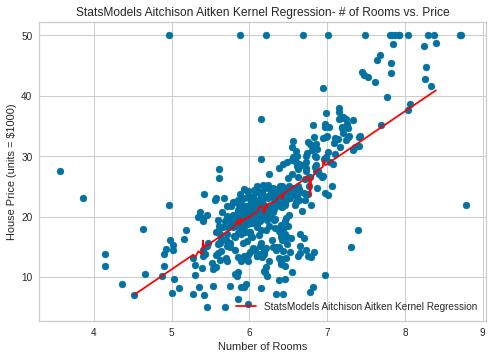

```python
graphResults("StatsModels Aitchison Aitken Kernel Regression", X, y, X_test_reshape, yhat_AAR)
```

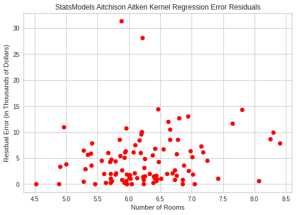

```python
yhat_AAR = yhat_AAR.reshape((dat_test[:,0].shape[0]), 1)
graphResiduals("StatsModels Aitchison Aitken Kernel Regression", X_test_reshape, y_test_reshape, yhat_AAR)
```

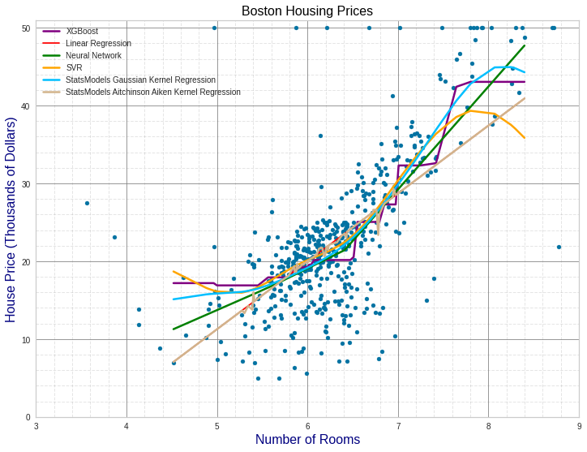

```python
fig, ax = plt.subplots(figsize=(12,9))
ax.set_xlim(3, 9)
ax.set_ylim(0, 51)
ax.scatter(X, y,s=25)
ax.plot(X_test_reshape, y_pred_xgb, color = 'purple', lw = 2.5, label = 'XGBoost')
ax.plot(X_test_reshape, y_pred_lr, color='red',label='Linear Regression')
ax.plot(X_test_reshape, y_pred_nn, color='green',lw=2.5,label='Neural Network')
ax.plot(X_test_reshape, y_pred_SVR, color='orange',lw=2.5,label='SVR')
ax.plot(X_test_reshape,yhat_smG,color='deepskyblue',lw=2.5,label='StatsModels Gaussian Kernel Regression')
ax.plot(X_test_reshape,yhat_AAR,color="tan",lw=2.5,label='StatsModels Aitchinson Aiken Kernel Regression')
ax.set_xlabel('Number of Rooms',fontsize=16,color='navy')
ax.set_ylabel('House Price (Thousands of Dollars)',fontsize=16,color='navy')
ax.set_title('Boston Housing Prices',fontsize=16,color='Black')
ax.grid(b=True,which='major', color ='grey', linestyle='-', alpha=0.8)
ax.grid(b=True,which='minor', color ='grey', linestyle='--', alpha=0.2)
ax.minorticks_on()
plt.legend()
```

## Model Comparison

```python
printMetrics("Linear Regression", y_test_reshape, y_pred_lr)
```

```
*Linear Regression* Metrics:
Mean absolute error = $ 4682.29
Mean squared error = $ 48384.8
Median absolute error = $ 3435.9
R2 score = 0.54
```

```python
printMetrics("XGBoost", y_test_reshape, y_pred_xgb)
```

```
*XGBoost* Metrics:
Mean absolute error = $ 4761.46
Mean squared error = $ 46046.96
Median absolute error = $ 3849.78
R2 score = 0.56
```

```python
printMetrics("Support Vector Regression", y_test_reshape, y_pred_SVR)
```

```
*Support Vector Regression* Metrics:
Mean absolute error = $ 4759.22
Mean squared error = $ 48990.48
Median absolute error = $ 3214.07
R2 score = 0.53
```

```python
printMetrics("Neural Net", y_test_reshape, y_pred_nn)
```

```
*Neural Net* Metrics:
Mean absolute error = $ 4443.44
Mean squared error = $ 43386.81
Median absolute error = $ 3493.35
R2 score = 0.59
```

```python
printMetrics("StatsModels Gaussian Kernel Regression", y_test_reshape, yhat_smG)
```

```
*StatsModels Gaussian Kernel Regression* Metrics:
Mean absolute error = $ 4499.81
Mean squared error = $ 43790.51
Median absolute error = $ 3372.68
R2 score = 0.58
```

```python
printMetrics("StatsModels Aitchison Aiken Kernel Regression", y_test_reshape, yhat_AAR)
```

```
*StatsModels Aitchison Aiken Kernel Regression* Metrics:
Mean absolute error = $ 4718.79
Mean squared error = $ 48673.24
Median absolute error = $ 3235.59
R2 score = 0.53
```

Overall, the Neural Net has the best R2 score, while the Support Vector regression has the lowest Median absolute error.

Most of the models have an R2 close to .5, which indicates they are not performing much better than a linear model. More hyperparameter tuning would be needed in the future to produce more accurate models that have lower errors.